# Smoothing and regression splines

Adrià Casanova, Silvia Ferrer, Matteo Mazzini

2024-12-08

```r
# load data and libraries
load("bikes.Washington.Rdata")
attach(bikes)
library(splines)
library(caret)
source('IRWLS logistic regression.R')
set.seed(42)
x <- instant
y <- cnt
```

# Exercice 1

We can first plot cnt against instant to see how they are distributed.

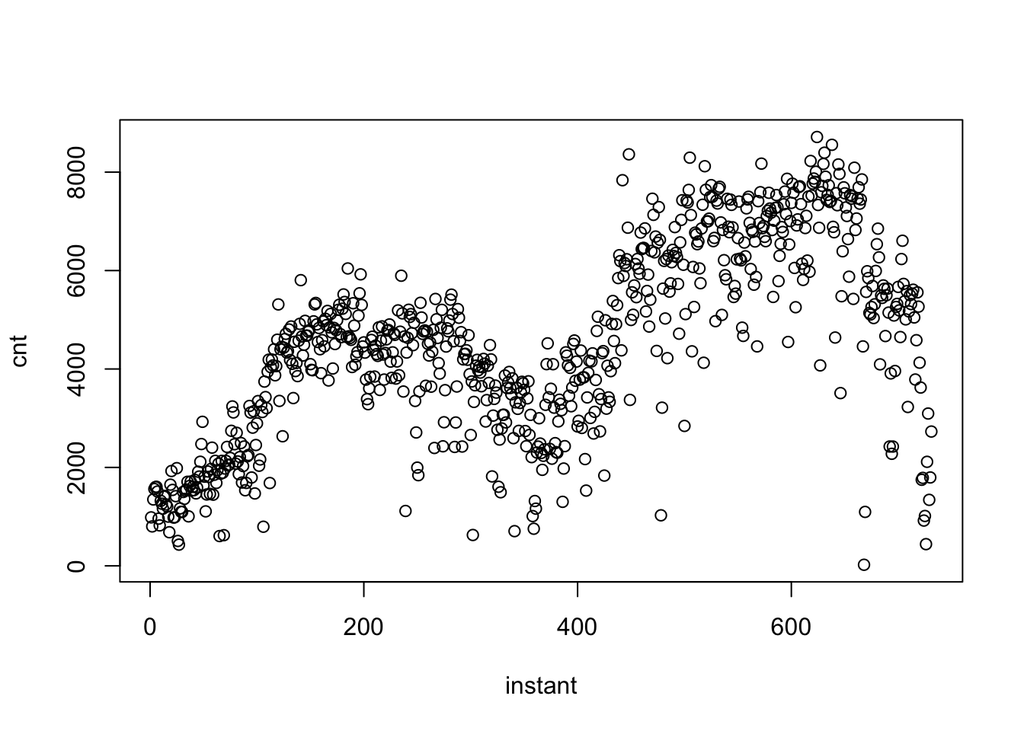

```r
plot(cnt~instant)
```

There seems to be a yearly pattern where many bikes are rented in summer and few in winter. Moreover, in 2012 more bikes were rented overall than in 2011.

```r
sm.spline.1 <- smooth.spline(x,y, cv = FALSE, all.knots = FALSE)
#a)
paste0("lambda value: ", sm.spline.1$lambda)
```

```
## [1] "lambda value: 1.00503770328244e-07"
```

```r
#b)
paste0("Equivalent number of df: ", round(sm.spline.1$df,2))
```

```
## [1] "Equivalent number of df: 93.34"
```

```r
#c)
paste0("Number of knots used: ", sm.spline.1$fit$nk)
```

```
## [1] "Number of knots used: 136"
```

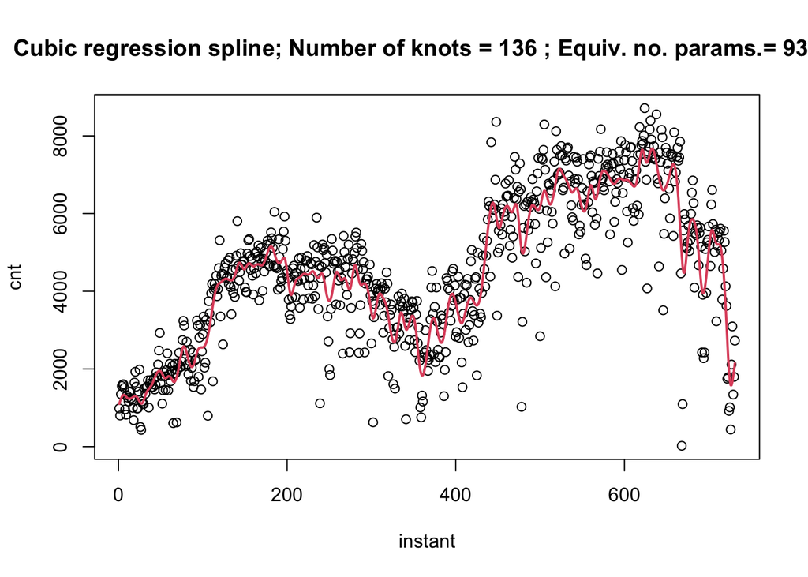

```r
#d)
plot(x , y,
     main=paste("Cubic regression spline; Number of knots =",sm.spline.1$fit$nk,
                "; Equiv. no. params.=",round(sm.spline.1$df,2)),
     xlab = "instant", ylab = "cnt")
lines(sm.spline.1,col=2,lwd=2)
```

Visually, it seems that smooth.spline has overfitted the data, since the fitted spline has too many local minima and maxima. Moreover, the number of knots and the equivalent number of parameters are very high.

# Exercice 2

We can first plot cnt against temp to see how they are distributed.

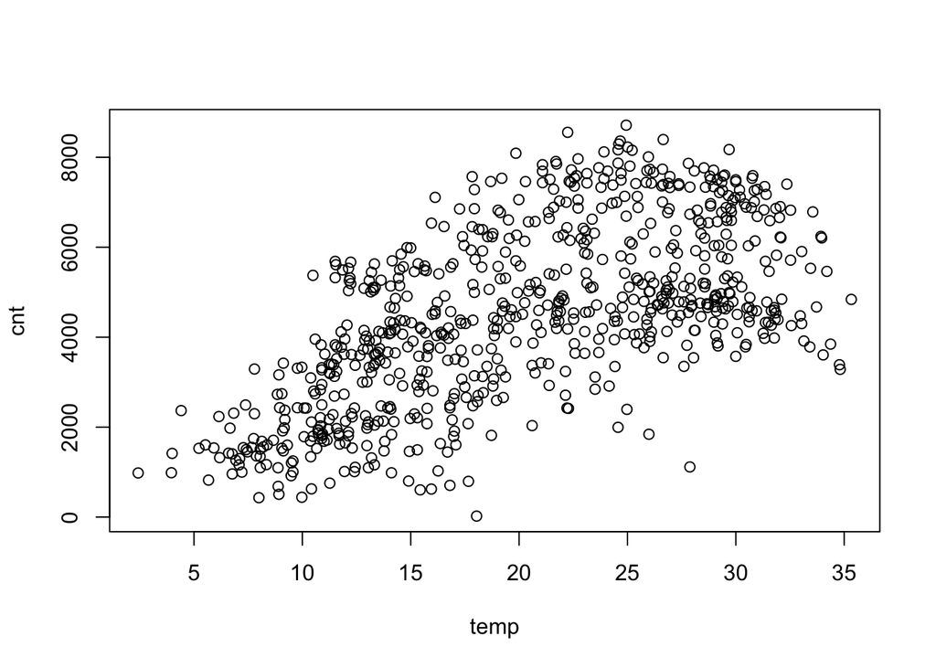

```r
plot(cnt~temp)
```

A priori, it looks like the total amount of rented bikes increases in warm days, but then decreases when the temperatures are very high. The least amount of bikes are rented on cold days.

## a)

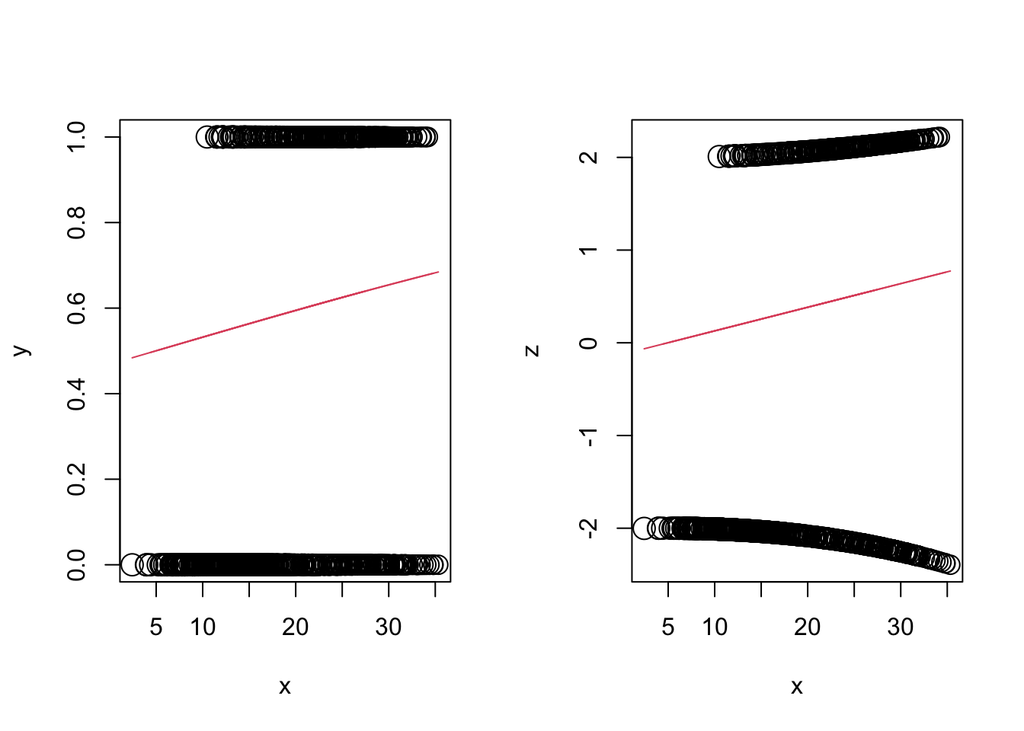

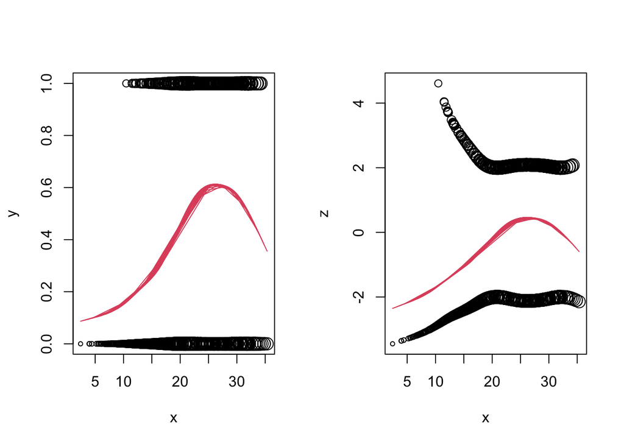

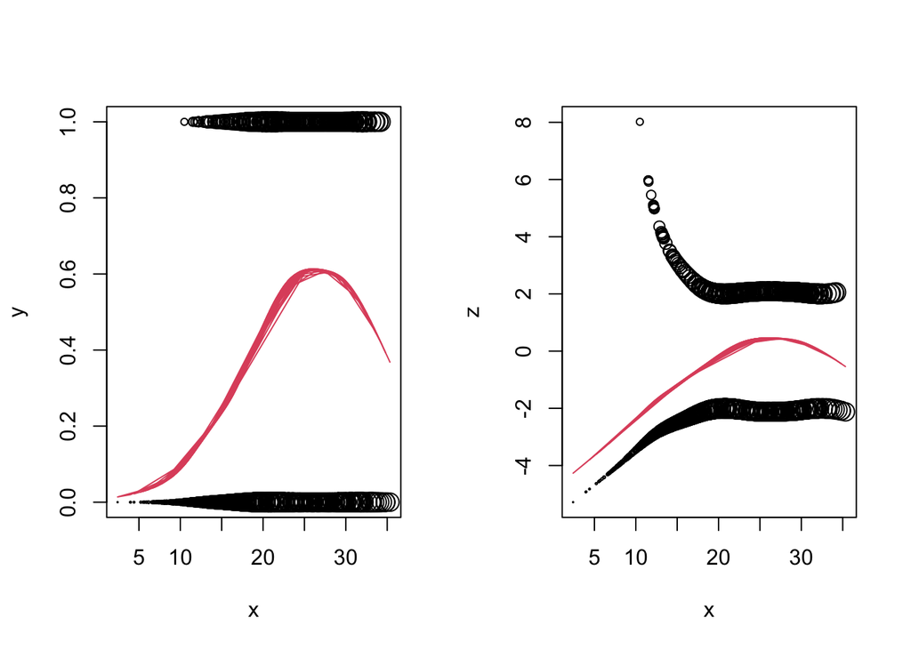

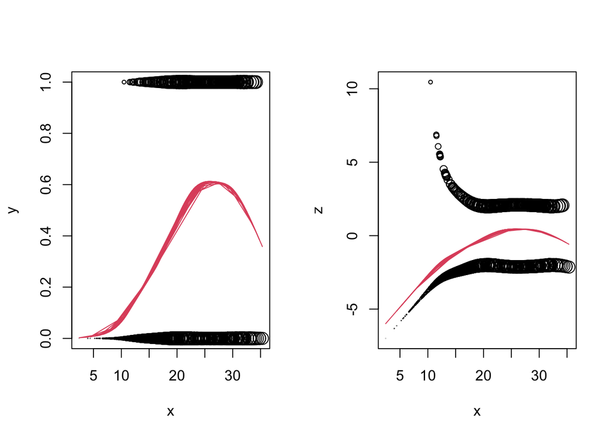

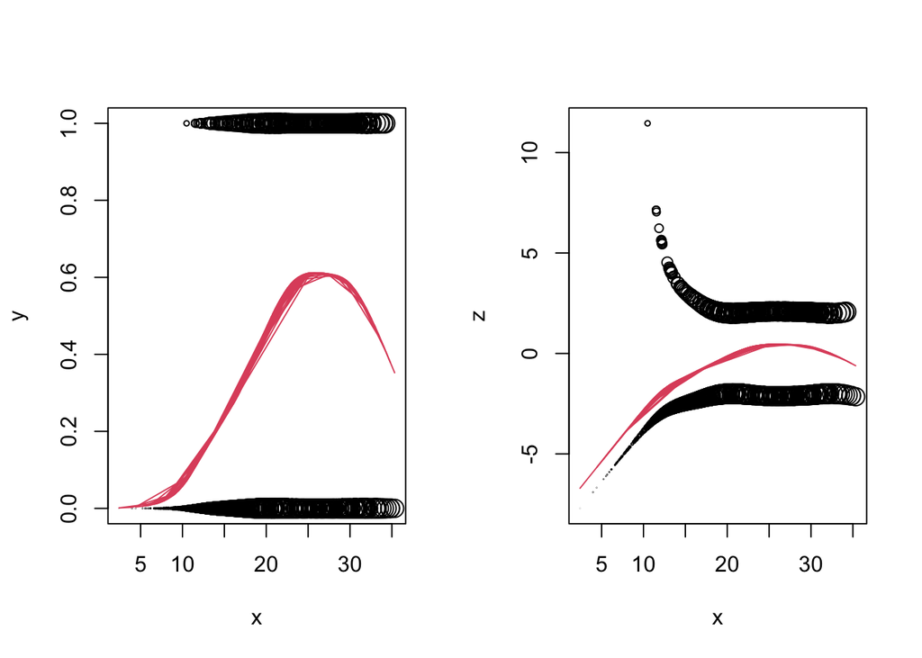

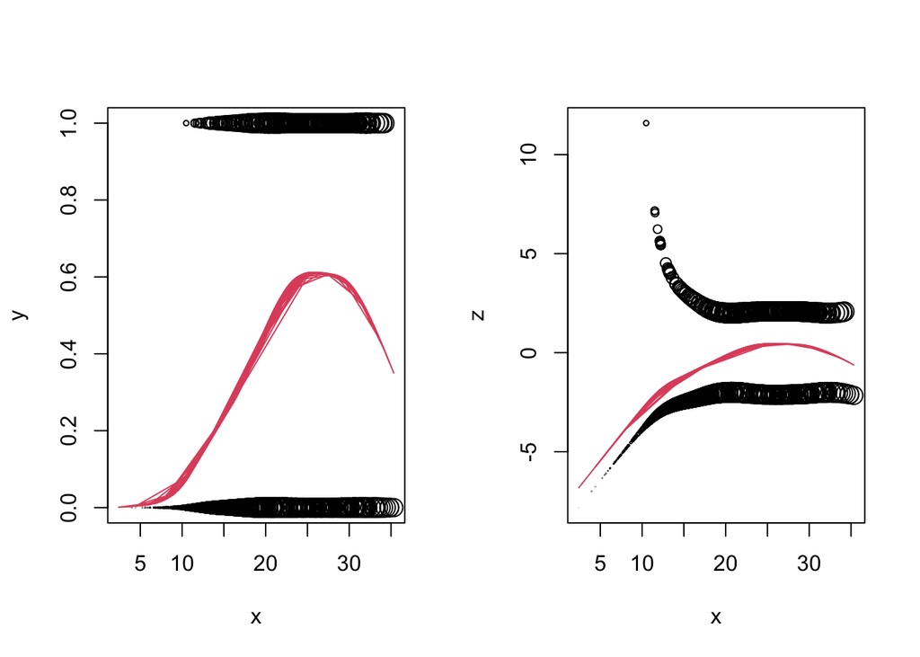

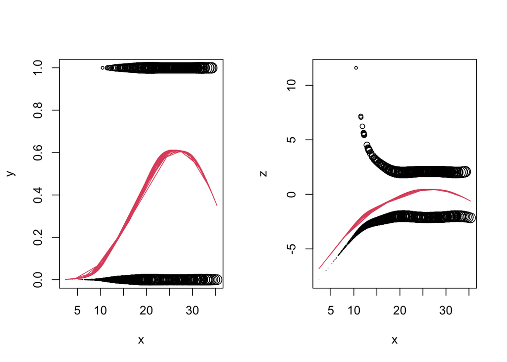

```r
cnt.5000 <- as.numeric(cnt >= 5000)
x.new <- seq(-30,50,by=.01)
cnt.temp.spline <- logistic.IRWLS.splines(x=temp, y=cnt.5000, x.new=x.new
                                          , df=6, plts=TRUE)
```

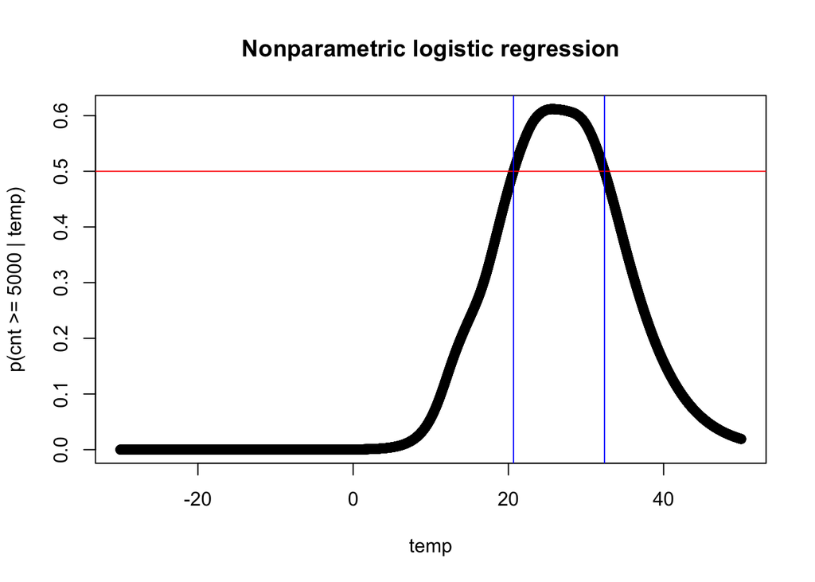

```r
temp.cnt.larger.5 <- cnt.temp.spline$predicted.values > 0.5
min.temp.cnt.larger.5 <- min(x.new[temp.cnt.larger.5])
max.temp.cnt.larger.5 <- max(x.new[temp.cnt.larger.5])

plot(x.new, cnt.temp.spline$predicted.values, xlab='temp'
     , ylab='p(cnt >= 5000 | temp)', main = 'Nonparametric logistic regression')
abline(h=.5, col="red")
abline(v=min.temp.cnt.larger.5, col="blue")
abline(v=max.temp.cnt.larger.5, col="blue")
```

$Pr(cnt > 5000 \mid temp) > 0.5$ when $temp \in [\texttt{20.66}, \texttt{32.38}]$.

## b)

```r
df.v <- 3:15
k <- 5
# Shuffle data and create 5 folds
folds <- createFolds(cnt.5000, k = k, list = TRUE)

log_lik <- sapply(df.v, function(df) {
  fold_ll <- sapply(1:k, function(fold) {
    train_idx <- unlist(folds[-fold])
    test_idx <- folds[[fold]]

    # Fit model on training data
    model <- logistic.IRWLS.splines(
      x = temp[train_idx],
      y = cnt.5000[train_idx],
      x.new = temp[test_idx],
      df = df,
      plts = FALSE
    )

    # Compute log-likelihood on validation data
    prob <- model$predicted.values # Predicted probabilities
    actual <- cnt.5000[test_idx]
    ll <- sum(actual * log(prob) + (1 - actual) * log(1 - prob))
    return(ll)
  })
  mean(fold_ll) # Average log-likelihood for this df
})

# Optimal df
best_df <- df.v[which.max(log_lik)]
cat("Best df:", best_df, "\n")
```

```
## Best df: 5
```

We can see how well the rest of values of df perform:

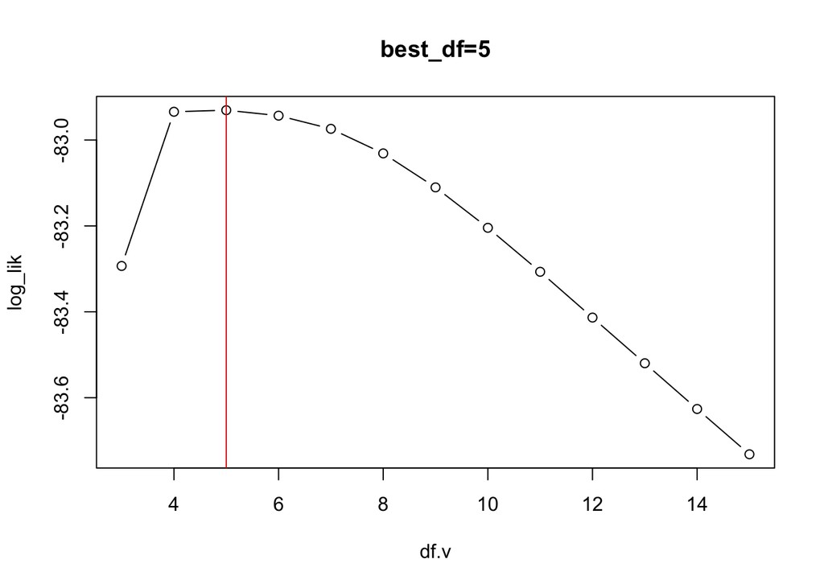

```r
plot(df.v, log_lik, type="b", main=paste0("best_df=",best_df))
abline(v=best_df, col="red")
```

Now, we repeat exercise a) with the optimal df value found.

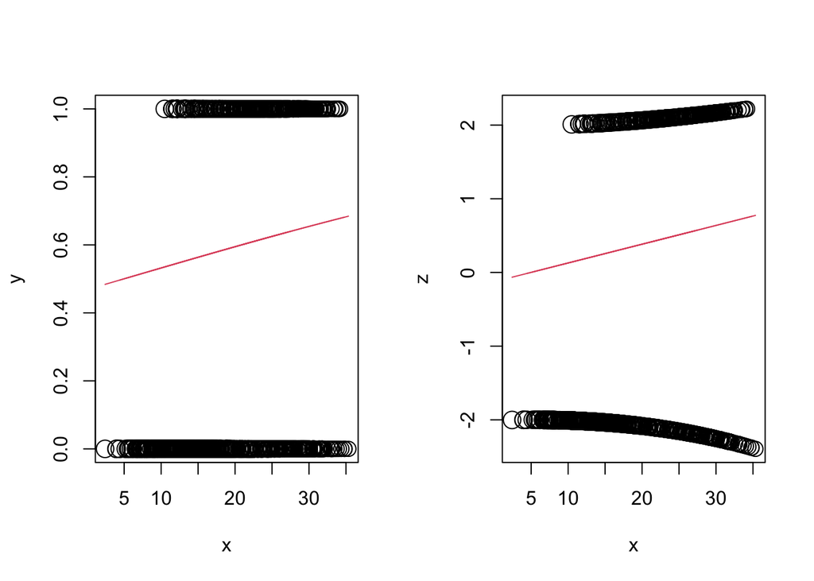

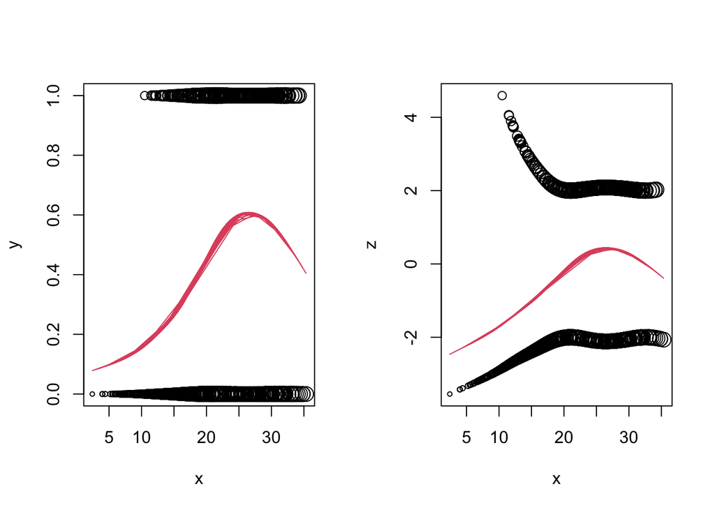

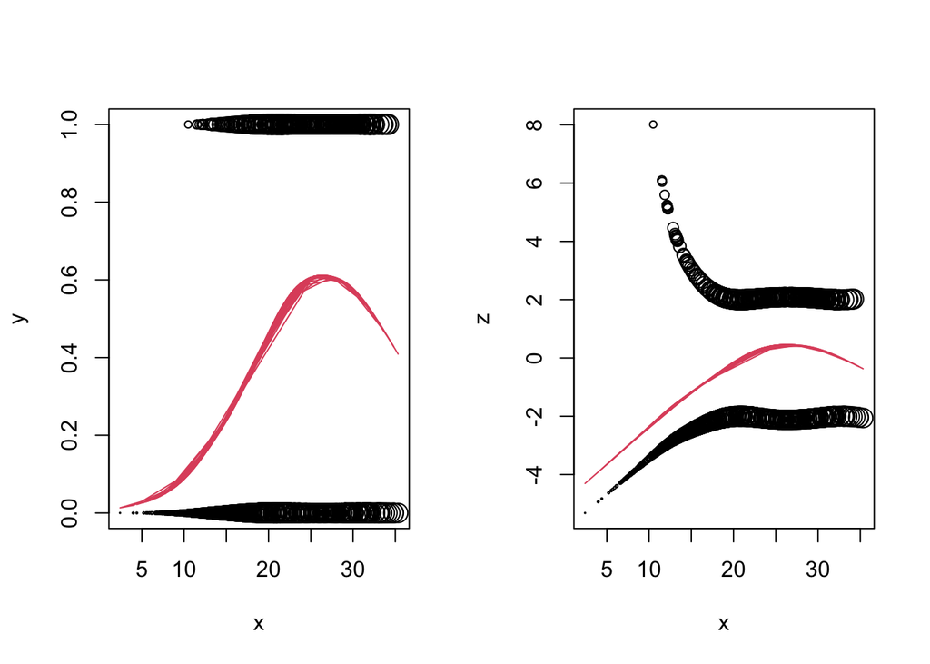

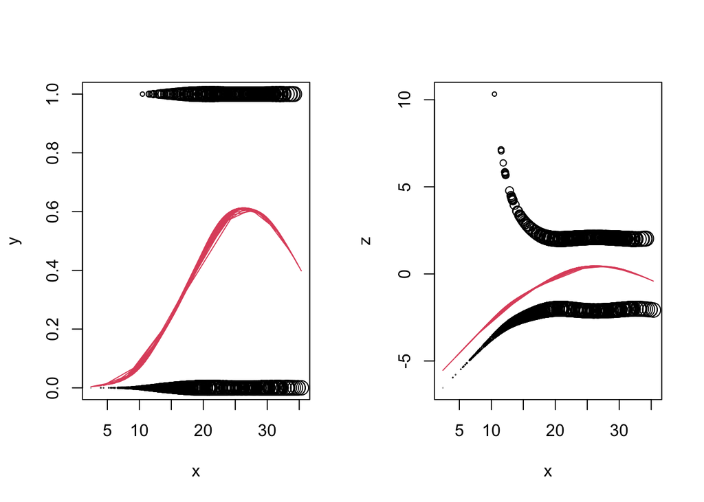

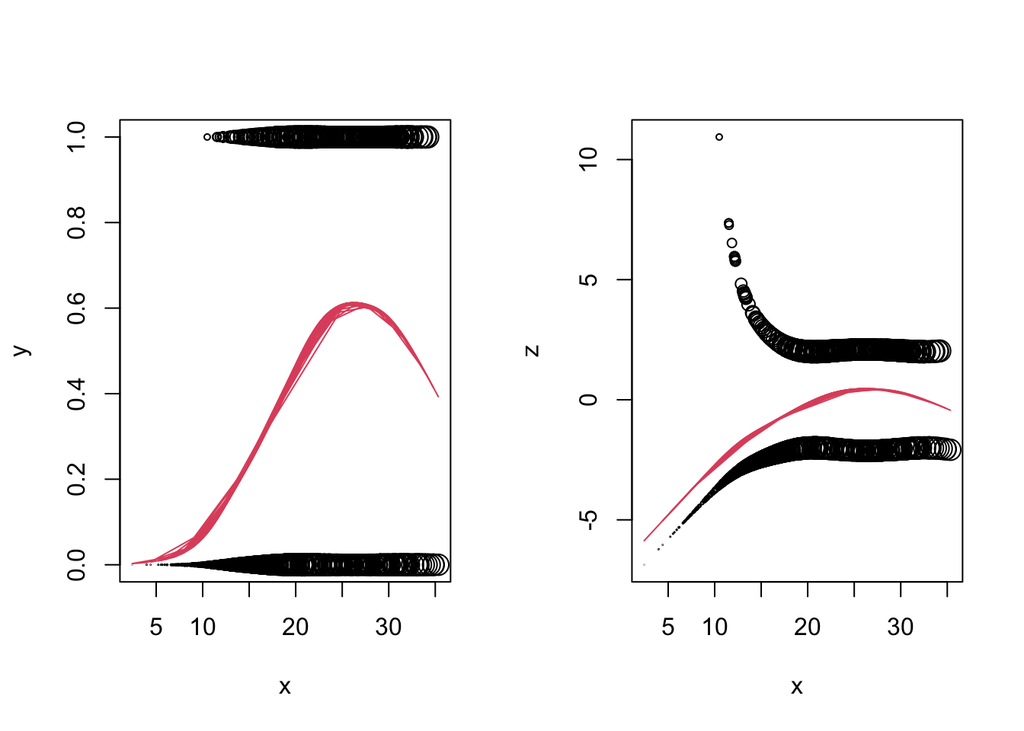

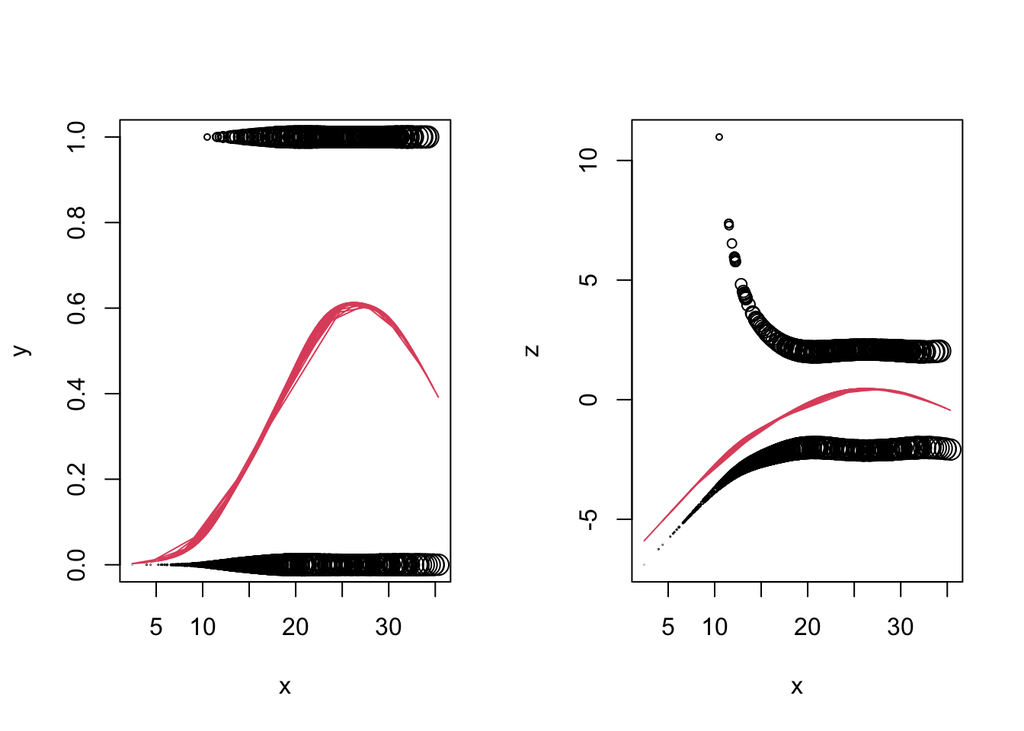

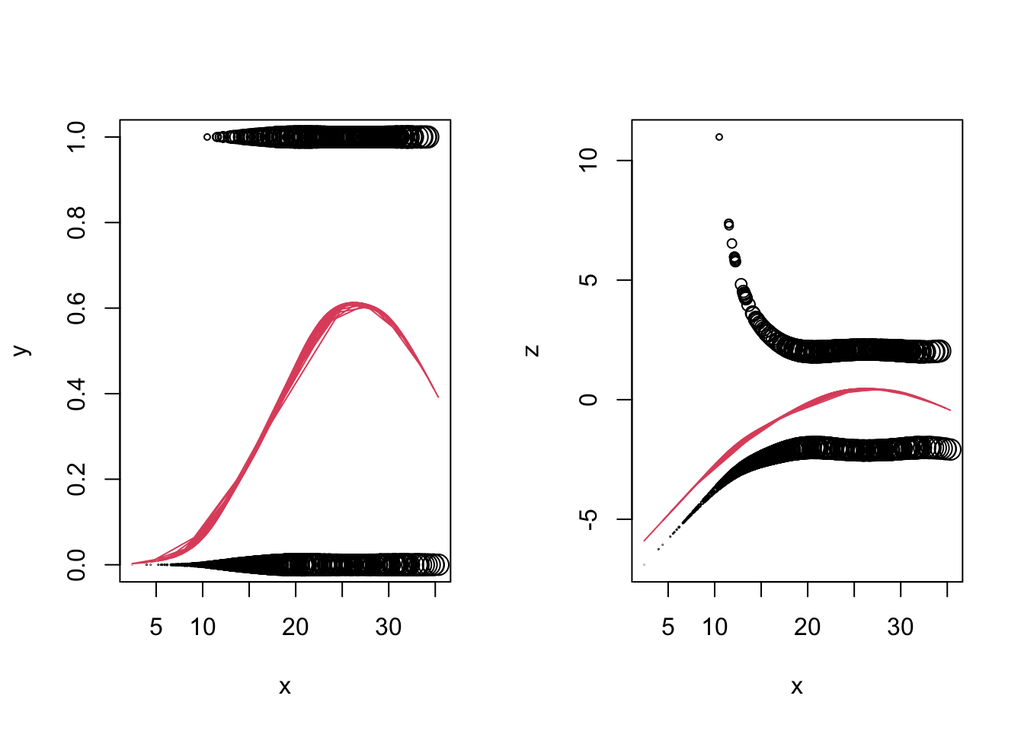

```r
# Repeat logistic non-parametric regression
cnt.temp.spline <- logistic.IRWLS.splines(x=temp, y=cnt.5000, x.new=x.new
                                          , df=best_df, plts=TRUE)
```

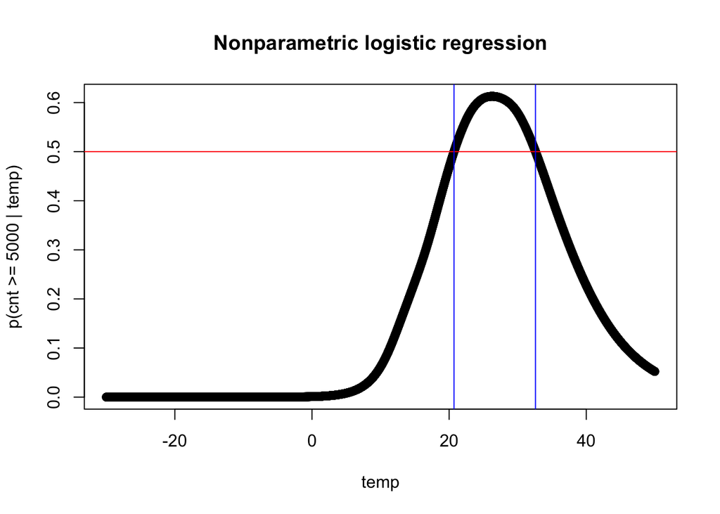

```r
temp.cnt.larger.5 <- cnt.temp.spline$predicted.values > 0.5
min.temp.cnt.larger.5 <- min(x.new[temp.cnt.larger.5])
max.temp.cnt.larger.5 <- max(x.new[temp.cnt.larger.5])

plot(x.new, cnt.temp.spline$predicted.values, xlab='temp'
     , ylab='p(cnt >= 5000 | temp)', main = 'Nonparametric logistic regression')
abline(h=.5, col="red")
abline(v=min.temp.cnt.larger.5, col="blue")
abline(v=max.temp.cnt.larger.5, col="blue")
```

$Pr(cnt > 5000 \mid temp) > 0.5$ when $temp \in [\texttt{20.71}, \texttt{32.59}]$.

The range of temperatures where $Pr(cnt > 5000 \mid temp) > 0.5$ has changed slightly from [20.66, 32.38] to [20.71, 32.59]. Overall, we can see that in warm days more than 5000 bikes are rented in total. However, if the temperature is higher than 33 ºC, then less bikes are rented.